# Unsupervised Learning

## 비지도 학습

비지도학습이란 **데이터가 레이블(정답)을 갖고 있지 않거나, 모두 같은 레이블 인 경우를 학습하는 것을 말합니다.**

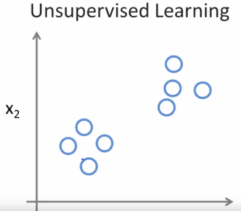

그래서 우리는 데이터로 무엇을 할지, 어떻게 예측을 할지 판단하기 힘들 것입니다. 단지 데이터가 두 가지 다른 클러스터(군집)으로 이뤄져 있다고 판단할 수 있다.

비지도학습 알고리즘은 이 데이터가 두가지 서로 다른 클러스터로 이루어 져있다는 것만 알수있고 이것을 **군집화** 라고 부른다.

다른 문제들에서도 비지도학습은 많이 사용된다.

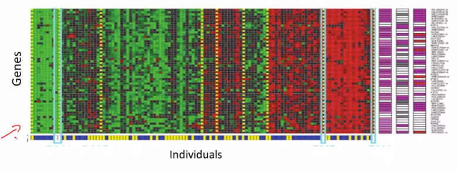

이것을 군집화 알고리즘을 통해 사람들을 서로 다른 분류 또는 타입으로 묶을 수 있다.

비지도 학습은 이렇게 유전자들의 특성에따라 1번 특성, 2번 특성, 3번 특성 처럼 알려주지 않고,  
*'여기 데이터가 엄청나게 있는데 누구의 데이턴지 어떤 데이터 인지, 사람들에게 어떤 타입의 데이터들이 나타날 수 있는지 모르는데, 이 데이터에서 구조를 찾아내서 각자 타입으로 클러스터링 해줄 수 있겠니?'*  
하는것이다

알고리즘에게 데이터 집합에 대한 정답을 알려 주지 않기 때문에 이건 비지도 학습이다.

군집화는 여러 곳에서 쓰입니다. **고객의 특성에따른 세분화, SNS 데이터를 통해 누가 적절한 친구 관계인지 ? , 천문학 데이터 분석등등..**

### Cocktail party problem

어떤 칵테일 파티에서 두 사람이 동시에 이야기를 하고 있을수 있는데,  
작은 규모의 칵테일 파티에서 방에 2개의 마이크를 둔다.  
마이크는 말하는 사람으로 부터 서로 다른 거리에 있기 때문에 각 마이크는 말하는 두사람의 목소리를 서로 다른조합으로 녹화하게 된다.  
1번 마이크는 1번 사람과 가깝게 녹음되고 2번 마이크는 2번 사람과 가깝게 녹음된다.

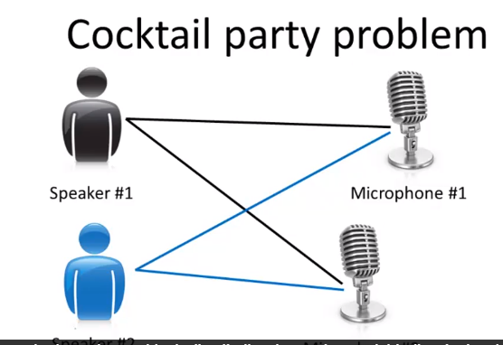

녹음된 두개의 소리를 알고리즘에게 *구조를 찾아줘!* 라고 한다면,  
알고리즘은 이 두 음성녹음을 들어보고 이것이 두 음석녹음이 더해져서, 또는 합쳐져서 우리가 가진 녹음이 되는 것같다고 말할것이다. 더 나아가 알고리즘은 두개의 음성 소스를 분리 낼 것이다.

두개의 음성을 완벽하게 분리하기 위해서는 c++이나 java로 복잡한 방식으로 구현 되어야 할것이다 라고 생각할 수 있다. 그러나 다음과 같은 단 한줄로 분리가 가능하다.

(여기서 굳이 c++ 이나 java 만 언급한 이유는 python이 발전 되기 전에 찍은 강의라서 그런거같다.)

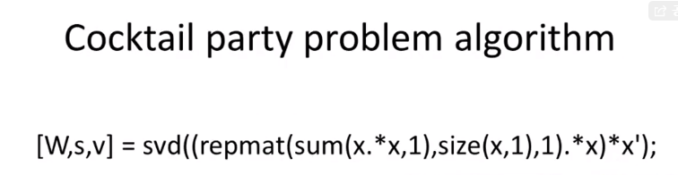

물론 한 줄의 코드를 만드는데 많은 시간이 소모 되었기에, 이 문제가 쉽다고 말할 수 없다.  
그러나 우리가 적당한 프로그래밍 환경을 사용한다면 많은 학습 알고리즘들을 간단히 프로그래밍 할 수 있을 것이다.